# Cars4U Project

*Objectives*

To explore and visualize the dataset, build a linear regression model to predict the prices of used cars, and generate a set of insights and recommendations that will help the business

**Data Discription**

The data contains the different attributes of used cars sold in different locations. The detailed data dictionary is given below.

S.No.: Serial number

- Name: Name of the car which includes brand name and model name
- Location: Location in which the car is being sold or is available for purchase (cities)
- Year: Manufacturing year of the car
- Kilometers_driven: The total kilometers driven in the car by the previous owner(s) in km
- Fuel_Type: The type of fuel used by the car (Petrol, Diesel, Electric, CNG, LPG)
- Transmission: The type of transmission used by the car (Automatic/Manual)
- Owner: Type of ownership
- Mileage: The standard mileage offered by the car company in kmpl or km/kg
- Engine: The displacement volume of the engine in CC
- Power: The maximum power of the engine in bhp
- Seats: The number of seats in the car
- New_Price: The price of a new car of the same model in INR Lakhs (1 Lakh INR = 100,000 INR)
- Price: The price of the used car in INR Lakhs

## Key Question

- Pricing model that can effectively predict the price of used cars and can help the business in devising profitable strategies.

# Loading libraries

```python
# this will help in making the Python code more structured automatically (good coding practice)
%load_ext nb_black

# Libraries to help with reading and manipulating data
import numpy as np
import pandas as pd

# For Removing Warning from Visuals
import warnings

warnings.filterwarnings("ignore")
# Libraries to help with data visualization
import matplotlib.pyplot as plt
import seaborn as sns

sns.set()

# Removes the limit for the number of displayed columns
pd.set_option("display.max_columns", None)
# Sets the limit for the number of displayed rows
pd.set_option("display.max_rows", 200)

# to split the data into train and test
from sklearn.model_selection import train_test_split

# to build linear regression_model
from sklearn.linear_model import LinearRegression

# to check model performance
from sklearn.metrics import mean_absolute_error, mean_squared_error, r2_score
```

# Loading and exploring the data

In this section the goals are to load the data into python and then to check its basic properties. This will include the dimension, column types and names, and missingness counts.

```python
# loading the dataset
data = pd.read_csv("used_cars_data.csv")
```

```python
# checking the shape of the data
print(f"There are {data.shape[0]} rows and {data.shape[1]} columns.")  # f-string
```

```
There are 7253 rows and 14 columns.
```

```python
# let's view a sample of the data
data.sample(
    10, random_state=2
)  # setting the random_state will ensure we get the same results every time
```

|  | S.No. | Name | Location | Year | Kilometers_Driven | Fuel_Type | Transmission | Owner_Type | Mileage | Engine | Power | Seats | New_Price | Price |
| --- | --- | --- | --- | --- | --- | --- | --- | --- | --- | --- | --- | --- | --- | --- |
| 4584 | 4584 | Tata Tigor 1.05 Revotorq XT | Kochi | 2018 | 28973 | Diesel | Manual | First | 24.7 kmpl | 1047 CC | 69 bhp | 5.0 | 7.15 | 6.64 |
| 6505 | 6505 | Volkswagen Vento Diesel Highline | Chennai | 2011 | 76041 | Diesel | Manual | First | 20.54 kmpl | 1598 CC | 103.6 bhp | 5.0 | 13.23 | NaN |
| 3675 | 3675 | Maruti Swift VDI | Ahmedabad | 2012 | 65000 | Diesel | Manual | First | 22.9 kmpl | 1248 CC | 74 bhp | 5.0 | 7.88 | 3.90 |
| 5654 | 5654 | Hyundai i20 Magna Optional 1.2 | Kochi | 2014 | 42315 | Petrol | Manual | First | 18.5 kmpl | 1197 CC | 82.9 bhp | 5.0 | 10.25 | 4.79 |
| 4297 | 4297 | Toyota Camry 2.5 G | Mumbai | 2014 | 68400 | Petrol | Automatic | First | 12.98 kmpl | 2494 CC | 178.4 bhp | 5.0 | 40.62 | 13.50 |
| 2603 | 2603 | Mercedes-Benz New C-Class 220 CDI AT | Jaipur | 2010 | 74213 | Diesel | Automatic | First | 14.84 kmpl | 2143 CC | 170 bhp | 5.0 | 49.49 | 11.50 |
| 4337 | 4337 | Volkswagen Vento Petrol Highline AT | Kochi | 2014 | 32283 | Petrol | Automatic | Second | 14.4 kmpl | 1598 CC | 103.6 bhp | 5.0 | 13.23 | 5.41 |
| 6625 | 6625 | Maruti Swift VDI BSIV | Kolkata | 2012 | 72000 | Diesel | Manual | First | 17.8 kmpl | 1248 CC | NaN | 5.0 | 7.88 | NaN |
| 2846 | 2846 | Skoda Superb Elegance 1.8 TSI AT | Kochi | 2011 | 73783 | Petrol | Automatic | Second | 13.7 kmpl | 1798 CC | 157.75 bhp | 5.0 | 33.36 | 5.23 |
| 1237 | 1237 | Audi Q3 2.0 TDI Quattro | Hyderabad | 2013 | 60000 | Diesel | Automatic | First | 17.32 kmpl | 1968 CC | 184 bhp | 5.0 | 44.80 | 21.00 |

Observation:

- The `Mileage` column has values in Kmpl and km/kg .
- The `Seats` column has a float of values.
- There are a lot of missing values.

```python
# creating a copy of the data so that original data remains unchanged
df = data.copy()
```

```python
# checking for duplicate values in the data
df.duplicated().sum()
```

```
0
```

Observation:

- There are no duplicate values in the data.

```python
# checking the names of the columns in the data
print(df.columns)
```

```
Index(['S.No.', 'Name', 'Location', 'Year', 'Kilometers_Driven', 'Fuel_Type',
       'Transmission', 'Owner_Type', 'Mileage', 'Engine', 'Power', 'Seats',
       'New_Price', 'Price'],
      dtype='object')
```

```python
# checking column datatypes and number of non-null values
df.info()
```

```
<class 'pandas.core.frame.DataFrame'>
RangeIndex: 7253 entries, 0 to 7252
Data columns (total 14 columns):
 #   Column             Non-Null Count  Dtype
---  ------             --------------  -----
 0   S.No.              7253 non-null   int64
 1   Name               7253 non-null   object
 2   Location           7253 non-null   object
 3   Year               7253 non-null   int64
 4   Kilometers_Driven  7253 non-null   int64
 5   Fuel_Type          7253 non-null   object
 6   Transmission       7253 non-null   object
 7   Owner_Type         7253 non-null   object
 8   Mileage            7251 non-null   object
 9   Engine             7207 non-null   object
 10  Power              7078 non-null   object
 11  Seats              7200 non-null   float64
 12  New_Price          7253 non-null   float64
 13  Price              6019 non-null   float64
dtypes: float64(3), int64(3), object(8)
memory usage: 793.4+ KB
```

Observation:

- There is lot of object variable needs to be converted in categorical.

```python
# Check Nulls
df.isnull().sum()
```

```
S.No.                   0
Name                    0
Location                0
Year                    0
Kilometers_Driven       0
Fuel_Type               0
Transmission            0
Owner_Type              0
Mileage                 2
Engine                 46
Power                 175
Seats                  53
New_Price               0
Price                1234
dtype: int64
```

Observation:

```python
# Let's look at the statistical summary of the data
df.describe(include="all").T
```

|  | count | unique | top | freq | mean | std | min | 25% | 50% | 75% | max |
| --- | --- | --- | --- | --- | --- | --- | --- | --- | --- | --- | --- |
| S.No. | 7253.0 | NaN | NaN | NaN | 3626.0 | 2093.905084 | 0.0 | 1813.0 | 3626.0 | 5439.0 | 7252.0 |
| Name | 7253 | 2041 | Mahindra XUV500 W8 2WD | 55 | NaN | NaN | NaN | NaN | NaN | NaN | NaN |
| Location | 7253 | 11 | Mumbai | 949 | NaN | NaN | NaN | NaN | NaN | NaN | NaN |
| Year | 7253.0 | NaN | NaN | NaN | 2013.365366 | 3.254421 | 1996.0 | 2011.0 | 2014.0 | 2016.0 | 2019.0 |
| Kilometers_Driven | 7253.0 | NaN | NaN | NaN | 58699.063146 | 84427.720583 | 171.0 | 34000.0 | 53416.0 | 73000.0 | 6500000.0 |
| Fuel_Type | 7253 | 5 | Diesel | 3852 | NaN | NaN | NaN | NaN | NaN | NaN | NaN |
| Transmission | 7253 | 2 | Manual | 5204 | NaN | NaN | NaN | NaN | NaN | NaN | NaN |
| Owner_Type | 7253 | 4 | First | 5952 | NaN | NaN | NaN | NaN | NaN | NaN | NaN |
| Mileage | 7251 | 450 | 17.0 kmpl | 207 | NaN | NaN | NaN | NaN | NaN | NaN | NaN |
| Engine | 7207 | 150 | 1197 CC | 732 | NaN | NaN | NaN | NaN | NaN | NaN | NaN |
| Power | 7078 | 385 | 74 bhp | 280 | NaN | NaN | NaN | NaN | NaN | NaN | NaN |
| Seats | 7200.0 | NaN | NaN | NaN | 5.279722 | 0.81166 | 0.0 | 5.0 | 5.0 | 5.0 | 10.0 |
| New_Price | 7253.0 | NaN | NaN | NaN | 21.307322 | 24.256314 | 3.91 | 7.88 | 11.3 | 21.69 | 375.0 |
| Price | 6019.0 | NaN | NaN | NaN | 9.479468 | 11.187917 | 0.44 | 3.5 | 5.64 | 9.95 | 160.0 |

Observation:

- Price of the used car is skewed towards right becuase 75% is almost eqaul of mean price of used car.
- No of seat is also skewed towards right same as 75% is equal to mean value.

### From the data overview, we see that many columns in the data need to be preprocessed before they can be used for analysis.

# Data Preprocessing

### I will drop the missing values in `price` column as it is the target variable.

```python
df.dropna(subset=["Price"], inplace=True)
```

```python
# I am going to reset the dataframe index
df.reset_index(inplace=True, drop=True)
```

```python
# checking missing values in rest of the data
df.isnull().sum()
```

```
S.No.                  0
Name                   0
Location               0
Year                   0
Kilometers_Driven      0
Fuel_Type              0
Transmission           0
Owner_Type             0
Mileage                2
Engine                36
Power                143
Seats                 42
New_Price              0
Price                  0
dtype: int64
```

# Variable Transformation

```python
# Going to remove CC from Engine and going to make it as numerical value
def eng_clean(engine):
    if isinstance(engine, str):
        return float(engine.replace("CC", "").strip())
    else:
        return np.nan


df["Engine"] = df["Engine"].apply(eng_clean)
```

```python
# Going to remove bph from Power and make it as a numerical value
def pow_clean(power):
    if isinstance(power, str):
        if power.replace("bhp", "").strip() != "null":
            return float(power.replace("bhp", "").strip())
        elif power.replace("bhp", "").strip() == "null":
            return np.nan
    else:
        return np.nan


df["Power"] = df["Power"].apply(pow_clean)
```

```python
# Is loop is used for to get Make out the Name because it will give a clear picture of make than Name column
blah = []
for row, sentence in enumerate(df["Name"]):
    if sentence.split(" ")[0] == "Land":
        blah.append(" ".join(sentence.split(" ")[0:2]))
    elif sentence.split(" ")[0] == "OpelCorsa":
        blah.append("Opel")
    elif sentence.split(" ")[0] == "ISUZU":
        blah.append("Isuzu")
    else:
        blah.append(sentence.split(" ")[0])
df["Make"] = blah
del blah
```

```python
# I am going to create a loop for Mileage to remove Km/Kg and Kmpl to make it consist for all, also it will give me a float value which is perfect for analysis.
def con_mileage(mileage):
    if isinstance(mileage, str):
        if mileage.endswith("g"):
            con = 0.7  # estimating density of 0.7 kg/m^3 for CNG at 200 bar i.e. -> 1L = 0.7kg
            return float(mileage.replace("km/kg", "").strip()) * con
        else:
            con = 1
            return float(mileage.replace("kmpl", "").strip()) * con
    else:
        return np.nan


df["Mileage"] = df["Mileage"].apply(con_mileage)
```

```python
# Now I am going to drop 3 columns 'New_Price', 'Serial No', 'Name' from the Datafram, that i am not going to use for my further analysis
df.drop(["S.No.", "Name", "New_Price"], axis=1, inplace=True)
```

```python
# I am going to check my updated Dataframe
df.sample(10)
```

|  | Location | Year | Kilometers_Driven | Fuel_Type | Transmission | Owner_Type | Mileage | Engine | Power | Seats | Price | Make |
| --- | --- | --- | --- | --- | --- | --- | --- | --- | --- | --- | --- | --- |
| 3287 | Pune | 2015 | 87900 | Diesel | Manual | First | 16.00 | 2179.0 | 140.00 | 7.0 | 12.01 | Mahindra |
| 2323 | Delhi | 2016 | 36676 | CNG | Manual | First | 17.50 | 1197.0 | 81.86 | 5.0 | 5.00 | Hyundai |
| 3986 | Kochi | 2018 | 32709 | Petrol | Manual | First | 18.16 | 1196.0 | 86.80 | 5.0 | 6.46 | Ford |
| 369 | Bangalore | 2009 | 90000 | Diesel | Automatic | Second | 11.00 | 2993.0 | 235.00 | 5.0 | 17.75 | BMW |
| 5404 | Pune | 2010 | 170000 | Diesel | Automatic | Third | 18.48 | 1995.0 | 177.00 | 5.0 | 12.00 | BMW |
| 210 | Kolkata | 2013 | 45000 | Diesel | Manual | First | 27.40 | 1498.0 | 98.60 | 5.0 | 3.25 | Honda |
| 3282 | Hyderabad | 2016 | 48000 | Petrol | Manual | First | 25.17 | 799.0 | 53.30 | 5.0 | 3.40 | Renault |
| 3650 | Chennai | 2013 | 123000 | Diesel | Manual | Second | 17.80 | 1399.0 | 67.00 | 5.0 | 4.45 | Ford |
| 4380 | Coimbatore | 2016 | 60913 | Petrol | Manual | First | 20.73 | 1373.0 | 91.10 | 5.0 | 7.19 | Maruti |
| 1149 | Kochi | 2016 | 51672 | Petrol | Manual | First | 19.50 | 1199.0 | 88.76 | 5.0 | 5.68 | Honda |

### Working with Other Null Columns : Engine, Power, Seats

```python
# Mileage has 2 Missing values going to drop them
df = df.loc[df["Mileage"].notnull(), :]
```

### I will fill the missing values in `Power`,`Engine`and `Seat` columns by the median values beacuse they all are skewed towards right as observed in above dataframe discripton`. Same code is used for all Coulums to fill their null values because all have same charactertics for skewedness.

```python
df["Engine"].fillna(df["Engine"].median(), inplace=True)
```

```python
df["Power"].fillna(df["Power"].median(), inplace=True)
```

```python
df["Seats"].fillna(df["Seats"].median(), inplace=True)
```

### How data look like afte all `Data Engineering`

```python
# checking missing values after "Data Engineering"

df.isnull().sum()
```

```
Location             0
Year                 0
Kilometers_Driven    0
Fuel_Type            0
Transmission         0
Owner_Type           0
Mileage              0
Engine               0
Power                0
Seats                0
Price                0
Make                 0
dtype: int64
```

```python
df.info()
```

```
<class 'pandas.core.frame.DataFrame'>
Int64Index: 6017 entries, 0 to 6018
Data columns (total 12 columns):
 #   Column             Non-Null Count  Dtype
---  ------             --------------  -----
 0   Location           6017 non-null   object
 1   Year               6017 non-null   int64
 2   Kilometers_Driven  6017 non-null   int64
 3   Fuel_Type          6017 non-null   object
 4   Transmission       6017 non-null   object
 5   Owner_Type         6017 non-null   object
 6   Mileage            6017 non-null   float64
 7   Engine             6017 non-null   float64
 8   Power              6017 non-null   float64
 9   Seats              6017 non-null   float64
 10  Price              6017 non-null   float64
 11  Make               6017 non-null   object
dtypes: float64(5), int64(2), object(5)
memory usage: 611.1+ KB
```

### Now Car4U data is all clean and ready for Next level, which is EAD going to jump on it.

```python
# For Plotting purpose converting Catergoical data to Counts
make = np.unique(df['Make'], return_counts=True)
owner_Type = np.unique(df['Owner_Type'], return_counts=True)
Transmission = np.unique(df['Transmission'], return_counts=True)
Location = np.unique(df['Location'], return_counts=True)
Fuel_Type = np.unique(df['Fuel_Type'], return_counts=True)
```

# Exploratory Data Analysis

## Univariate Analysis

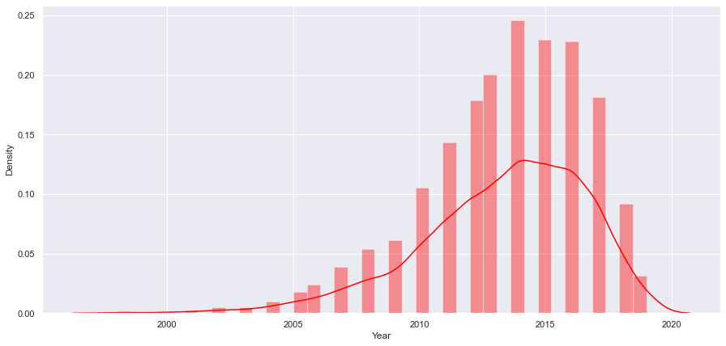

```python
plt.figure(figsize=(15, 7))
sns.distplot(df.Year, color="Red")
plt.show()
```

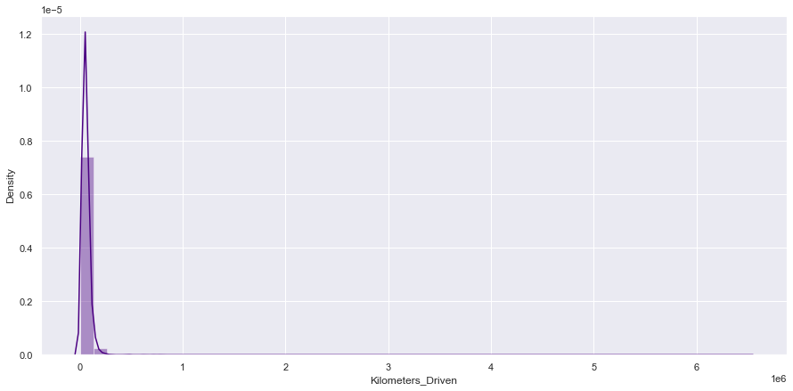

```python
plt.figure(figsize=(15, 7))
sns.distplot(df.Kilometers_Driven, color="Indigo")
plt.show()
```

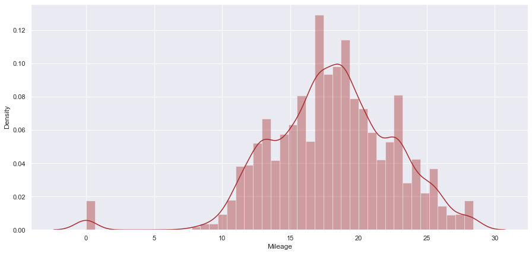

```python
plt.figure(figsize=(15, 7))
sns.distplot(df.Mileage, color="Brown")
plt.show()
```

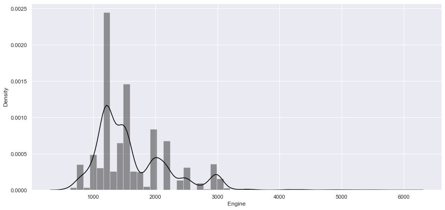

```python
plt.figure(figsize=(15, 7))
sns.distplot(df.Engine, color="Black")
plt.show()
```

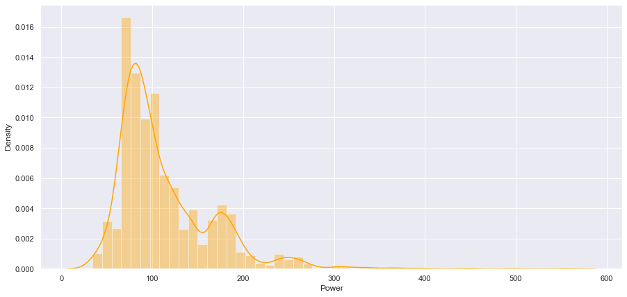

```python
plt.figure(figsize=(15, 7))
sns.distplot(df.Power, color="Orange")
plt.show()
```

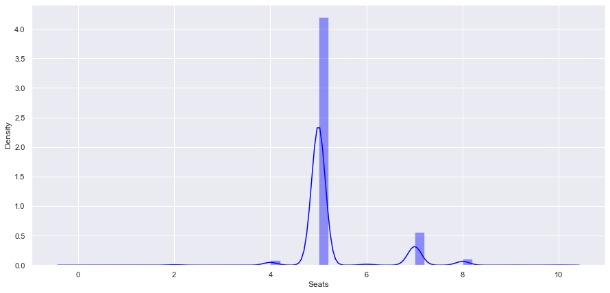

```python
plt.figure(figsize=(15, 7))
sns.distplot(df.Seats, color="Blue")
plt.show()
```

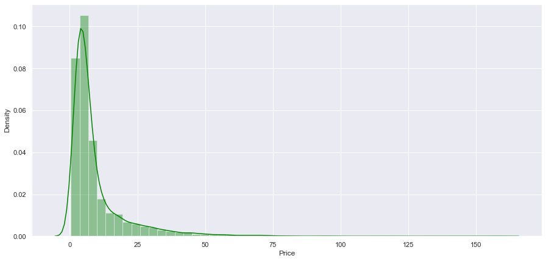

```python
plt.figure(figsize=(15, 7))
sns.distplot(df.Price, color="Green")
plt.show()
```

Observation:

## Multivariate Analysis

Looking at the relationship between differnt numerical variables 'Year', 'Power', 'Kilometers_Driven', 'Engine', 'Price', 'Seats'

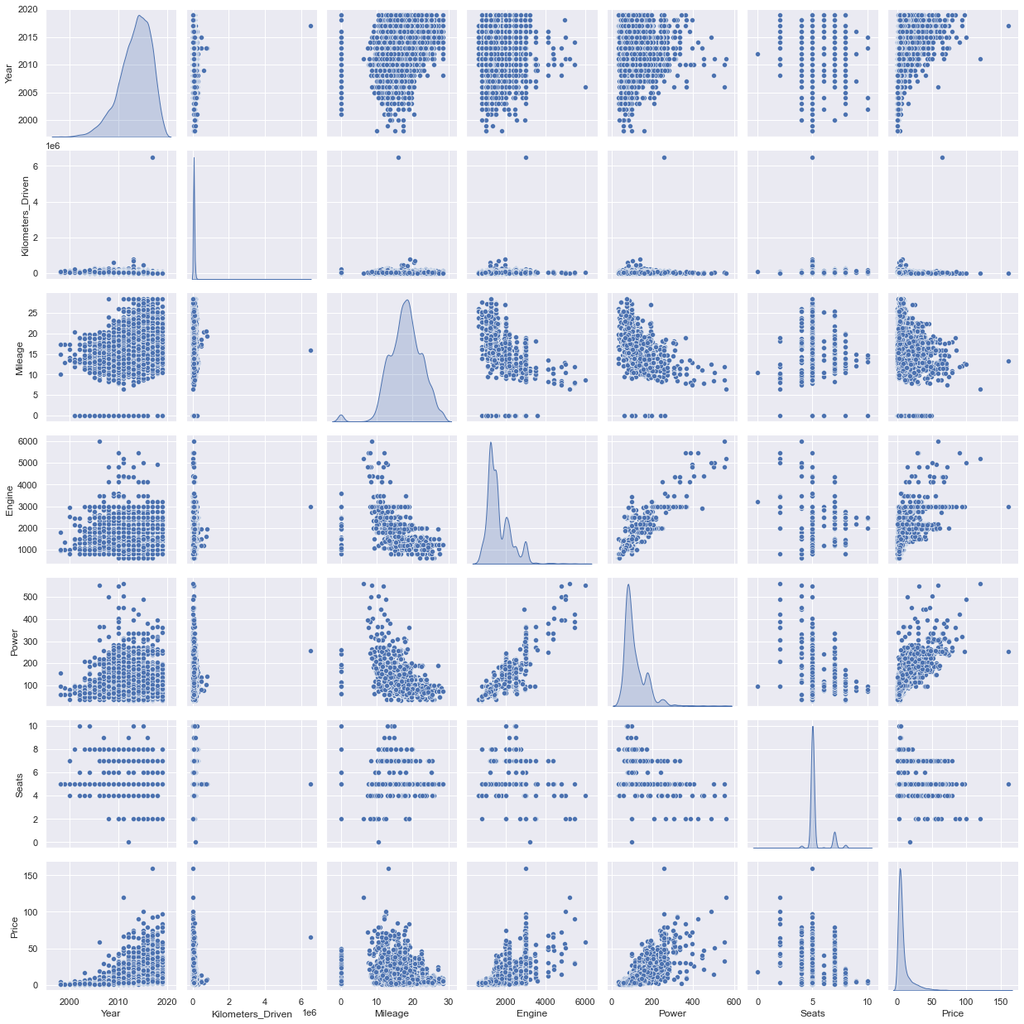

```python
sns.pairplot(df, diag_kind="kde")
```

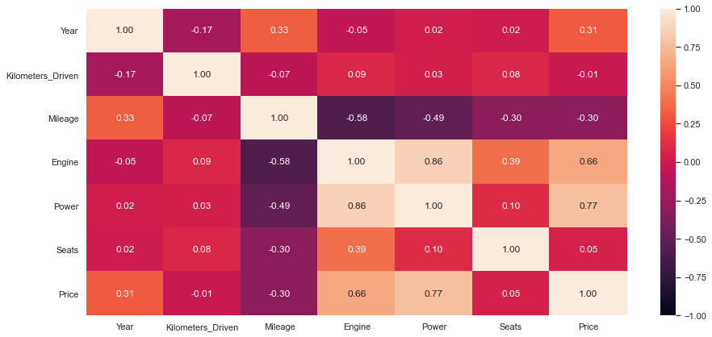

```python
plt.figure(figsize=(15, 7))
sns.heatmap(df.corr(), annot=True, vmin=-1, vmax=1, fmt=".2f")
plt.show()
```

### Relationship between 'Price', 'Owner_Type', 'Tansmission', "Fuel_Type

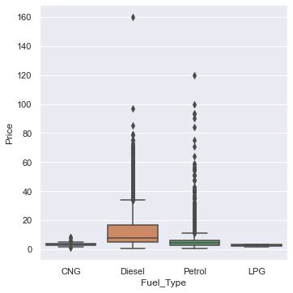

```python
plt.figure(figsize=(15, 5))
sns.catplot(x="Fuel_Type",
           y="Price",
           data=df,
           kind="box");
```

### Kilometers_Driven Trend at Make and Owner_Type

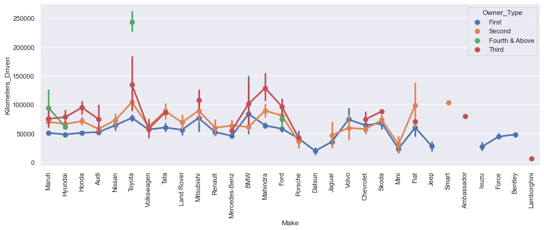

```python
plt.figure(figsize=(15, 5))
plt.xticks(rotation=90)
sns.pointplot(x="Make", y="Kilometers_Driven", hue="Owner_Type", data=df)
plt.show()
```

### Used Cars Sold by Location

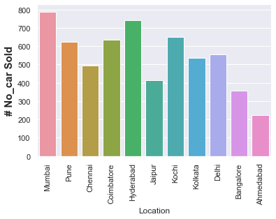

```python
plt.xticks(rotation=90)
sns.countplot(df["Location"])
plt.ylabel("# No_car Sold", fontsize=15, fontweight="bold")
plt.show()
```

### Used Cars Sold by Transmission

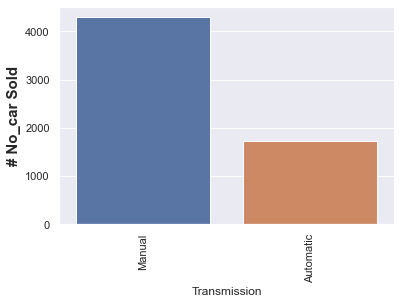

```python
plt.xticks(rotation=90)
sns.countplot(df["Transmission"])
plt.ylabel("# No_car Sold", fontsize=15, fontweight="bold")
plt.show()
```

### Used Cars Sold by Make

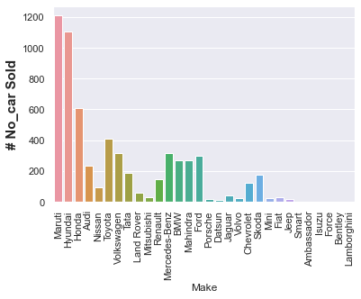

```python
plt.xticks(rotation=90)
sns.countplot(df["Make"])
plt.ylabel("# No_car Sold", fontsize=15, fontweight="bold")
plt.show()
```

## Exploratory Data Analysis Findings

- Customer used to buy Maruti, Hyundai, Honda, Ford, Toyota than other car becuase it is lower in cost, less price of car is more frequeuent than higher priced car.
- Customers prefer manual transmissions over automatic.
- Customers prefer to buy a car with of mileage range of 15 - 20 kmpl
- Ahmedabad,Jaipur and Bangalore dealerships are looks like underselling compared to other dealership locations like Delhi, Pune.
- Customer like ot buy car almost 5 to 10 years old.
- Customer like to buy car from 4 lahk to 11 lakh price range
- Number of seats 5 are most sold cars
- Price and Power are highly corelated.

## Outlier detection using Z-Score

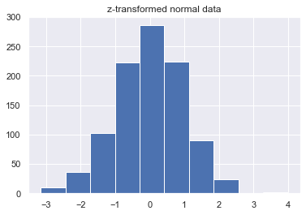

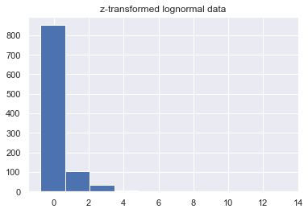

```python
def z_transform(x):
    return (x - np.mean(x)) / np.std(x)


np.random.seed(1)
x1 = np.random.normal(size=1000)
x2 = np.random.lognormal(size=1000)


plt.hist(z_transform(x1))
plt.title("z-transformed normal data")
plt.show()


plt.hist(z_transform(x2))
plt.title("z-transformed lognormal data")
plt.show()
```

All of the points in each plot are drawn from the exact same distribution, so it's not fair to call any of the points outliers in the sense of there being bad data. But depending on the distribution in question, we may have almost all of the z-scores between -3 and 3 or instead there could be extremely large values

## Log Transformation

Price, Power by log transformation, Kilometers_Driven is by square-root transformation

```python
df["Price"] = np.log(df["Price"])
df["Power"] = np.log(df["Power"])
df["Kilometers_Driven"] = np.sqrt(df["Kilometers_Driven"])
```

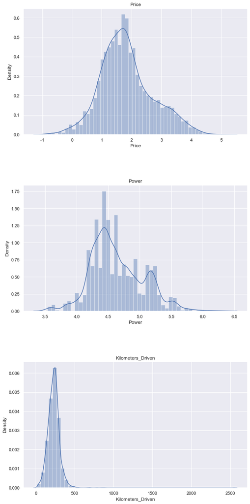

```python
# Plot team to see there distribution
fig = plt.figure(figsize=[10, 30])
grid = plt.GridSpec(4, 1, wspace=0.4, hspace=0.4)
x = ["Price", "Power", "Kilometers_Driven"]
for i, a in enumerate(x):
    exec(f"ax{i}0 = plt.subplot(grid[i,0]);")
    exec(f"sns.distplot(df[a], ax=ax{i}0);")
    exec(f"ax{i}0.set_title(a);")

fig.show()
```

Observation

- Distributions look good for the purposes of the linearity assumption.

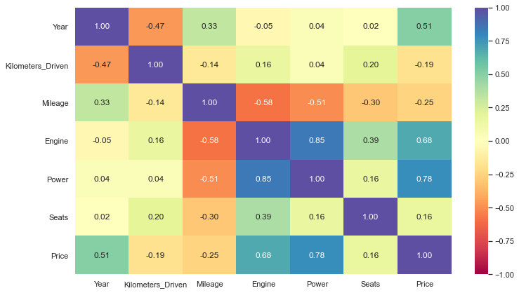

```python
plt.figure(figsize=(12, 7))
sns.heatmap(df.corr(), annot=True, vmin=-1, vmax=1, fmt=".2f", cmap="Spectral")
plt.show()
```

There are still a few highly correlated columns

## Dummies Variables

```python
df = pd.get_dummies(
    df,
    columns=["Location", "Fuel_Type", "Transmission", "Owner_Type", "Make"],
    drop_first=True,
)
```

## Linear Regression Model Building

### Dependent Variable

```python
X = df.drop(["Price"], axis=1)
y = df[["Price"]]
```

### Split data train and test

```python
from sklearn.model_selection import train_test_split

x_train, x_test, y_train, y_test = train_test_split(X, y, test_size=0.3, random_state=2)
```

```python
print("Number of rows in train data =", x_train.shape[0])
print("Number of rows in test data =", x_test.shape[0])
```

```
Number of rows in train data = 4211
Number of rows in test data = 1806
```

### Fitting a linear Regression Model

```python
lin_reg_model = LinearRegression()
lin_reg_model.fit(x_train, y_train)
```

```
LinearRegression()
```

**I am going to check the coefficients and intercept of the model

```python
coef_df = pd.DataFrame(
    np.append(lin_reg_model.coef_, lin_reg_model.intercept_),
    index=x_train.columns.tolist() + ["Intercept"],
    columns=["Coefficients"],
)
coef_df
```

|  | Coefficients |
| --- | --- |
| Year | 1.168676e-01 |
| Kilometers_Driven | -7.223188e-04 |
| Mileage | -5.665910e-03 |
| Engine | 1.848405e-04 |
| Power | 7.661502e-01 |
| Seats | 4.114646e-02 |
| Location_Bangalore | 1.403924e-01 |
| Location_Chennai | 2.437924e-02 |
| Location_Coimbatore | 8.860522e-02 |
| Location_Delhi | -8.812642e-02 |
| Location_Hyderabad | 1.286301e-01 |
| Location_Jaipur | -3.891884e-02 |
| Location_Kochi | -2.950179e-02 |
| Location_Kolkata | -2.395637e-01 |
| Location_Mumbai | -7.353590e-02 |
| Location_Pune | -4.089808e-02 |
| Fuel_Type_Diesel | 2.205239e-01 |
| Fuel_Type_LPG | -9.653869e-03 |
| Fuel_Type_Petrol | 2.354770e-02 |
| Transmission_Manual | -1.010908e-01 |
| Owner_Type_Fourth & Above | 6.231974e-02 |
| Owner_Type_Second | -6.670312e-02 |
| Owner_Type_Third | -1.644579e-01 |
| Make_Audi | 4.442686e-01 |
| Make_BMW | 3.780984e-01 |
| Make_Bentley | 8.283305e-16 |
| Make_Chevrolet | -4.893768e-01 |
| Make_Datsun | -5.582765e-01 |
| Make_Fiat | -4.499293e-01 |
| Make_Force | -1.363162e-01 |
| Make_Ford | -2.228952e-01 |
| Make_Honda | -1.920245e-01 |
| Make_Hyundai | -2.030019e-01 |
| Make_Isuzu | -3.024412e-01 |
| Make_Jaguar | 4.955551e-01 |
| Make_Jeep | -1.664114e-02 |
| Make_Lamborghini | -1.110223e-16 |
| Make_Land Rover | 6.902094e-01 |
| Make_Mahindra | -3.078777e-01 |
| Make_Maruti | -1.520664e-01 |
| Make_Mercedes-Benz | 4.326832e-01 |
| Make_Mini | 8.011222e-01 |
| Make_Mitsubishi | 2.928710e-02 |
| Make_Nissan | -2.080451e-01 |
| Make_Porsche | 8.415622e-01 |
| Make_Renault | -2.015438e-01 |
| Make_Skoda | -1.508365e-01 |
| Make_Smart | 1.982692e-02 |
| Make_Tata | -5.835131e-01 |
| Make_Toyota | 3.062843e-02 |
| Make_Volkswagen | -1.986456e-01 |
| Make_Volvo | 2.101892e-01 |
| Intercept | -2.372129e+02 |

### Model performance check

- I am using metric functions defined in sklearn for RMSE, MAE, and $R^2$.

```python
# function to compute adjusted R-squared
def adj_r2_score(predictors, targets, predictions):
    r2 = r2_score(targets, predictions)
    n = predictors.shape[0]
    k = predictors.shape[1]
    return 1 - ((1 - r2) * (n - 1) / (n - k - 1))


# function to compute MAPE
def mape_score(targets, predictions):
    return np.mean(np.abs(targets - predictions) / targets) * 100


# function to compute different metrics to check performance of a regression model
def model_performance_regression(model, predictors, target):
    """
    Function to compute different metrics to check regression model performance

    model: regressor
    predictors: independent variables
    target: dependent variable
    """

    # predicting using the independent variables
    pred = model.predict(predictors)

    r2 = r2_score(target, pred)  # to compute R-squared
    adjr2 = adj_r2_score(predictors, target, pred)  # to compute adjusted R-squared
    rmse = np.sqrt(mean_squared_error(target, pred))  # to compute RMSE
    mae = mean_absolute_error(target, pred)  # to compute MAE

    # creating a dataframe of metrics
    df_perf = pd.DataFrame(
        {"RMSE": rmse, "MAE": mae, "R-squared": r2, "Adj. R-squared": adjr2,},
        index=[0],
    )

    return df_perf
```

```python
# Checking model performance on train set
print("Training Performance\n")
lin_reg_model_train_perf = model_performance_regression(lin_reg_model, x_train, y_train)
lin_reg_model_train_perf
```

```
Training Performance
```

|  | RMSE | MAE | R-squared | Adj. R-squared |
| --- | --- | --- | --- | --- |
| 0 | 0.221959 | 0.166996 | 0.93489 | 0.934076 |

```python
# Checking model performance on test set
print("Test Performance\n")
lin_reg_model_test_perf = model_performance_regression(lin_reg_model, x_test, y_test)
lin_reg_model_test_perf
```

```
Test Performance
```

|  | RMSE | MAE | R-squared | Adj. R-squared |
| --- | --- | --- | --- | --- |
| 0 | 0.245128 | 0.168924 | 0.923042 | 0.920759 |

## Recommendations for Cars4U Business

Customer Analysis of by looking at the different Trends of attributes in data:

## Regresssion Model focus Conclusion

- Model provide accuracy of almost 90% for the pricing of the car that customer will willing to pay accoriding to different characteristics of te used car.
- Model is trustable to used by pricing team for future pricing setup.
- Model is also showing low error so it is good to have first pilot project to test in Dealership.